# Landuse Toolbox Data Exploration

This R Markdown aims at transparently exploring a correction of harvested area of toolbox landuse data.

The below code chunk does the basic library and data setup.

```r
## loading and baisc data setup
library(mrland)
library(scales)
library(tidyverse)
library(magrittr)

percent <- label_percent(accuracy = 0.001)

# read the data
harvestedArea <- readSource("LanduseToolbox", "harvestedArea")
physicalArea <- readSource("LanduseToolbox", "physicalArea")

#also read fallow land for conistency check
fallowArea <- calcOutput("FallowLand", aggregate = FALSE)

#extract some years to make everything faster
harvestedArea <- harvestedArea[, c("y1985","y2000", "y2015") ,]
physicalArea <-  physicalArea[, c("y1985", "y2000", "y2015") ,]
fallowArea <-  fallowArea[, c("y1985", "y2000", "y2015") ,]

#get rid of noncrops
non_crops <- c("pasture", "begr", "betr")
harvestedArea <- harvestedArea[, , non_crops, invert=T ]

# remove irrigation differentiation
harvestedAreaSum <- dimSums(harvestedArea, dim ="irrigation")
physicalAreaSum <-  dimSums(physicalArea, dim ="irrigation")
```

# Description of the correction

The harvested areas from the toolbox have some mismatches with the physical cropland from HYDE. That is, in some areas the physical area for annuals after subtraction of perennials is very small compared to harvested Area of annuals, so that the annuals CI can be very high. In addition, in some areas we have rainfed harvested area but (almost) no rainfed physical area, so the rainfed CIs can be extreme.

To deal with these problem the following correction to the harvested area is proposed. Everything is done for irrigated and rainfed crops separately, which is not written out to avoid too many formulas and notations. We want to enforce the constraints
$$perennialHarvestedArea \leq physicalArea$$
and
$$annaulsCI= \frac{annualsHarvestedArea}{physicalArea-perennialHarvestedArea} \leq 3$$
In cases where one of those constraints is not satisfied the harvested Area in the cell is scaled down by a factor (one for rainfed and one for irrigated) that is small enough to enforce both constraints. Plugging in the scaled down $annualsHarvestedArea\cdot x$ and $pernnailsHarvestedArea\cdot x$ in the above constraints and solving for x gives us
$$x\leq\frac{3\cdot physicalArea}{annualsHarvestedArea + 3\cdot perennialHarvestedArea}$$

Since we want to do as little change to the data as possible we choose

$$x= \min(1,\frac{3\cdot physicalArea}{annualsHarvestedArea + 3\cdot perennialHarvestedArea})$$
To avoid division by zero: In case of zero harvested area x is set to 1, so no change will be done.

# Apply the correction

```r
perennials <- c("sugr_cane", "oilpalm")


crops <- getItems(harvestedArea, dim = "crop")
annuals <- crops[!crops %in% perennials]



perennialHarvestedA <-  dimSums(harvestedArea[, , perennials], dim = c("crop"))
annualsHarvestedA <- dimSums(harvestedArea[, , perennials, invert=T], dim = c("crop"))


factor <- ifelse( annualsHarvestedA+perennialHarvestedA>0 ,
          3*physicalArea/
          ( annualsHarvestedA + 3*perennialHarvestedA),
          1)

factor[factor>1] <- 1


harvestedAreaCorrected <- harvestedArea * factor
```

# Loss of harvested area due to the correction

## Totals

### year 1985

Relative loss

```r
totalbefore <-  sum(harvestedArea[,"y1985", ])
totalafter <-  sum(harvestedAreaCorrected[,"y1985", ])


totalbefore_rainfed <-  sum(harvestedArea[,"y1985", "rainfed" ])
totalafter_rainfed <-  sum(harvestedAreaCorrected[,"y1985",  "rainfed" ])

totalbefore_irrigation <-  sum(harvestedArea[,"y1985","irrigated" ])
totalafter_irrigation <-  sum(harvestedAreaCorrected[,"y1985", "irrigated"  ])

cat( "Total area is reduced by:",
     percent( (totalafter - totalbefore) / totalbefore ), "\n"  )
```

```
## Total area is reduced by: -0.204%
```

```r
cat( "Irrigated area is reduced by:",
     percent( (totalafter_irrigation - totalbefore_irrigation) / totalbefore_irrigation ), "\n"  )
```

```
## Irrigated area is reduced by: -0.281%
```

```r
cat( "Rainfed area is reduced by:",
     percent( (totalafter_rainfed - totalbefore_rainfed) / totalbefore_rainfed )  )
```

```
## Rainfed area is reduced by: -0.185%
```

Absolute loss

```r
cat( "Total area is reduced by:",
      totalafter - totalbefore , "mHa \n"  )
```

```
## Total area is reduced by: -2.58 mHa
```

```r
cat( "Irrigated area is reduced by:",
      totalafter_irrigation - totalbefore_irrigation , "mHa \n"  )
```

```
## Irrigated area is reduced by: -0.684 mHa
```

```r
cat( "Rainfed area is reduced by:",
      totalafter_rainfed - totalbefore_rainfed, "mHa"   )
```

```
## Rainfed area is reduced by: -1.89 mHa
```

### year 2000

Relative loss

```r
totalbefore <-  sum(harvestedArea[,"y2000", ])
totalafter <-  sum(harvestedAreaCorrected[,"y2000", ])

totalbefore_rainfed <-  sum(harvestedArea[,"y2000", "rainfed" ])
totalafter_rainfed <-  sum(harvestedAreaCorrected[,"y2000",  "rainfed" ])

totalbefore_irrigation <-  sum(harvestedArea[,"y2000","irrigated" ])
totalafter_irrigation <-  sum(harvestedAreaCorrected[,"y2000", "irrigated"  ])

cat( "Total area is reduced by:",
     percent( (totalafter - totalbefore) / totalbefore ), "\n"  )
```

```
## Total area is reduced by: -0.246%
```

```r
cat( "Irrigated area is reduced by:",
     percent( (totalafter_irrigation - totalbefore_irrigation) / totalbefore_irrigation ), "\n"  )
```

```
## Irrigated area is reduced by: -0.273%
```

```r
cat( "Rainfed area is reduced by:",
     percent( (totalafter_rainfed - totalbefore_rainfed) / totalbefore_rainfed )  )
```

```
## Rainfed area is reduced by: -0.239%
```

Absolute loss

```r
cat( "Total area is reduced by:",
      totalafter - totalbefore , "mHa \n"  )
```

```
## Total area is reduced by: -3.21 mHa
```

```r
cat( "Irrigated area is reduced by:",
      totalafter_irrigation - totalbefore_irrigation , "mHa \n"  )
```

```
## Irrigated area is reduced by: -0.797 mHa
```

```r
cat( "Rainfed area is reduced by:",
      totalafter_rainfed - totalbefore_rainfed, "mHa"   )
```

```
## Rainfed area is reduced by: -2.41 mHa
```

### year 2015

Relative loss

```r
totalbefore <-  sum(harvestedArea[,"y2015", ])
totalafter <-  sum(harvestedAreaCorrected[,"y2015", ])

totalbefore_rainfed <-  sum(harvestedArea[,"y2015", "rainfed" ])
totalafter_rainfed <-  sum(harvestedAreaCorrected[,"y2015",  "rainfed" ])

totalbefore_irrigation <-  sum(harvestedArea[,"y2015","irrigated" ])
totalafter_irrigation <-  sum(harvestedAreaCorrected[,"y2015", "irrigated"  ])

cat( "Total area is reduced by:",
     percent( (totalafter - totalbefore) / totalbefore ), "\n"  )
```

```
## Total area is reduced by: -0.517%
```

```r
cat( "Irrigated area is reduced by:",
     percent( (totalafter_irrigation - totalbefore_irrigation) / totalbefore_irrigation ), "\n"  )
```

```
## Irrigated area is reduced by: -0.358%
```

```r
cat( "Rainfed area is reduced by:",
     percent( (totalafter_rainfed - totalbefore_rainfed) / totalbefore_rainfed )  )
```

```
## Rainfed area is reduced by: -0.563%
```

Absolute loss

```r
cat( "Total area is reduced by:",
      totalafter - totalbefore , "mHa \n"  )
```

```
## Total area is reduced by: -7.76 mHa
```

```r
cat( "Irrigated area is reduced by:",
      totalafter_irrigation - totalbefore_irrigation , "mHa \n"  )
```

```
## Irrigated area is reduced by: -1.21 mHa
```

```r
cat( "Rainfed area is reduced by:",
      totalafter_rainfed - totalbefore_rainfed, "mHa"   )
```

```
## Rainfed area is reduced by: -6.55 mHa
```

## Country level

### 1985

```r
loss <-   harvestedAreaCorrected- harvestedArea

lossCropSum <- dimSums(loss, dim = "crop")

lossCropIrrSum <- dimSums(lossCropSum, dim = "irrigation")

harvestedAreaCropSum <- dimSums( harvestedArea, dim= "crop")

harvestedAreaCropIrrSum <- dimSums( harvestedAreaCropSum, dim= "irrigation")

loss_rel <- lossCropSum / harvestedAreaCropSum

loss_rel_sum <- lossCropIrrSum/ harvestedAreaCropIrrSum

lossCropSum_dataframe <- as.data.frame( toolCoord2Isocell( lossCropSum ) )

harvestedArea_dataframe <- as.data.frame( toolCoord2Isocell( harvestedAreaCropSum ) )

lossCropSum_dataframe  %<>%   group_by(Region, Data1, Year) %>%  summarise( loss_mHa = sum(Value))

harvestedArea_dataframe  %<>%   group_by(Region, Data1, Year) %>%  summarise( harvestedArea = sum(Value))

combined <- left_join(lossCropSum_dataframe, harvestedArea_dataframe)

combined %<>%  pivot_wider(names_from = Data1, values_from = c(loss_mHa, harvestedArea)) %>%
  rename(loss_irrigated_mHa = loss_mHa_irrigated, loss_rainfed_mHa = loss_mHa_rainfed ) %>%
  mutate(loss_total_mHa = loss_irrigated_mHa + loss_rainfed_mHa,
         harvestedArea_total = harvestedArea_irrigated+ harvestedArea_rainfed) %>%
  mutate(`loss_rainfed_%` = loss_rainfed_mHa / harvestedArea_rainfed *100,
         `loss_irrigated_%` = loss_irrigated_mHa / harvestedArea_irrigated *100,
         `loss_total_%` = loss_total_mHa / harvestedArea_total *100)

combined_disp <- combined %>%  ungroup %>%
  select(Region, Year, `loss_total_%`, loss_total_mHa,  `loss_rainfed_%`, loss_rainfed_mHa, `loss_irrigated_%`, loss_irrigated_mHa )
```

Click on a column name to sort the rows by this column.

```r
combined_disp %>% filter(Year == "1985") %>% select(!Year) %>% arrange( `loss_total_%` ) %>%
  mutate_if(is.numeric, function(x)replace_na( round(x,3),0) ) %>% DT::datatable(. )
```

|  | Region | loss_total_% | loss_total_mHa | loss_rainfed_% | loss_rainfed_mHa | loss_irrigated_% | loss_irrigated_mHa |
| --- | --- | --- | --- | --- | --- | --- | --- |
| 1 | EGY | -28.457 | -1.199 | -99.184 | -1.199 | 0 | 0 |
| 2 | ARE | -22.681 | -0.005 | -83.18 | -0.005 | 0 | 0 |
| 3 | BLZ | -13.248 | -0.005 | -13.248 | -0.005 | 0 | 0 |
| 4 | SUR | -12.814 | -0.009 | -18.495 | -0.009 | 0 | 0 |
| 5 | CUB | -11.974 | -0.24 | 0 | 0 | -52.292 | -0.24 |
| 6 | TWN | -10.826 | -0.124 | -13.055 | -0.124 | 0 | 0 |
| 7 | GUY | -2.3 | -0.003 | 0 | 0 | -3.292 | -0.003 |
| 8 | NGA | -2.274 | -0.449 | -2.217 | -0.426 | -4.365 | -0.023 |
| 9 | SOM | -1.36 | -0.012 | 0 | 0 | -7.906 | -0.012 |
| 10 | PAN | -1.349 | -0.004 | 0 | 0 | -17.048 | -0.004 |

[output cut: 169 more lines]

### 2000

```r
combined_disp %>% filter(Year == "2000") %>% select(!Year) %>% arrange( `loss_total_%` ) %>%
  mutate_if(is.numeric, function(x)replace_na( round(x,3),0) ) %>% DT::datatable(. )
```

|  | Region | loss_total_% | loss_total_mHa | loss_rainfed_% | loss_rainfed_mHa | loss_irrigated_% | loss_irrigated_mHa |
| --- | --- | --- | --- | --- | --- | --- | --- |
| 1 | EGY | -21.152 | -1.182 | -99.253 | -1.182 | 0 | 0 |
| 2 | TKM | -15.845 | -0.287 | -58.246 | -0.287 | 0 | 0 |
| 3 | NCL | -13.847 | -0.001 | -21.033 | -0.001 | 0 | 0 |
| 4 | CUB | -11.737 | -0.239 | 0 | 0 | -51.534 | -0.239 |
| 5 | NPL | -5.824 | -0.247 | -7.814 | -0.247 | 0 | 0 |
| 6 | GUY | -3.831 | -0.007 | 0 | 0 | -5.19 | -0.007 |
| 7 | BLZ | -3.226 | -0.002 | -3.248 | -0.002 | 0 | 0 |
| 8 | TJK | -2.702 | -0.026 | -7.225 | -0.026 | 0 | 0 |
| 9 | PAN | -2.185 | -0.006 | 0 | 0 | -19.218 | -0.006 |
| 10 | SUR | -1.64 | -0.001 | -7.554 | -0.001 | 0 | 0 |

[output cut: 169 more lines]

### 2015

```r
combined_disp %>% filter(Year == "2015") %>% select(!Year) %>% arrange( `loss_total_%` ) %>%
  mutate_if(is.numeric, function(x)replace_na( round(x,3),0) ) %>% DT::datatable(. )
```

|  | Region | loss_total_% | loss_total_mHa | loss_rainfed_% | loss_rainfed_mHa | loss_irrigated_% | loss_irrigated_mHa |
| --- | --- | --- | --- | --- | --- | --- | --- |
| 1 | VUT | -87.101 | -0.008 | -100 | -0.008 | 0 | 0 |
| 2 | NCL | -59.837 | -0.007 | -99.076 | -0.007 | 0 | 0 |
| 3 | NZL | -30.495 | -0.106 | -96.027 | -0.106 | 0 | 0 |
| 4 | ARE | -28.74 | -0.027 | -99.695 | -0.027 | 0 | 0 |
| 5 | TKM | -26.649 | -0.725 | -86.313 | -0.725 | 0 | 0 |
| 6 | EGY | -24.645 | -1.635 | -87.494 | -1.635 | 0 | 0 |
| 7 | BGD | -12.472 | -1.765 | -20.191 | -1.765 | 0 | 0 |
| 8 | NPL | -11.188 | -0.533 | -17.843 | -0.533 | 0 | 0 |
| 9 | BLZ | -6.047 | -0.004 | -6.105 | -0.004 | 0 | 0 |
| 10 | CUB | -4.926 | -0.063 | 0 | 0 | -28.133 | -0.063 |

[output cut: 169 more lines]

## Cell level

Below a summary of the absolute loss.

```r
summary(lossCropSum)
```

```
##    Min. 1st Qu.  Median    Mean 3rd Qu.    Max.
##  -0.206   0.000   0.000   0.000   0.000   0.000
```

Below a summary of the relative loss.

```r
summary(loss_rel)
```

```
##    Min. 1st Qu.  Median    Mean 3rd Qu.    Max.    NA's
##      -1       0       0       0       0       0  258693
```

Plotted on maps:

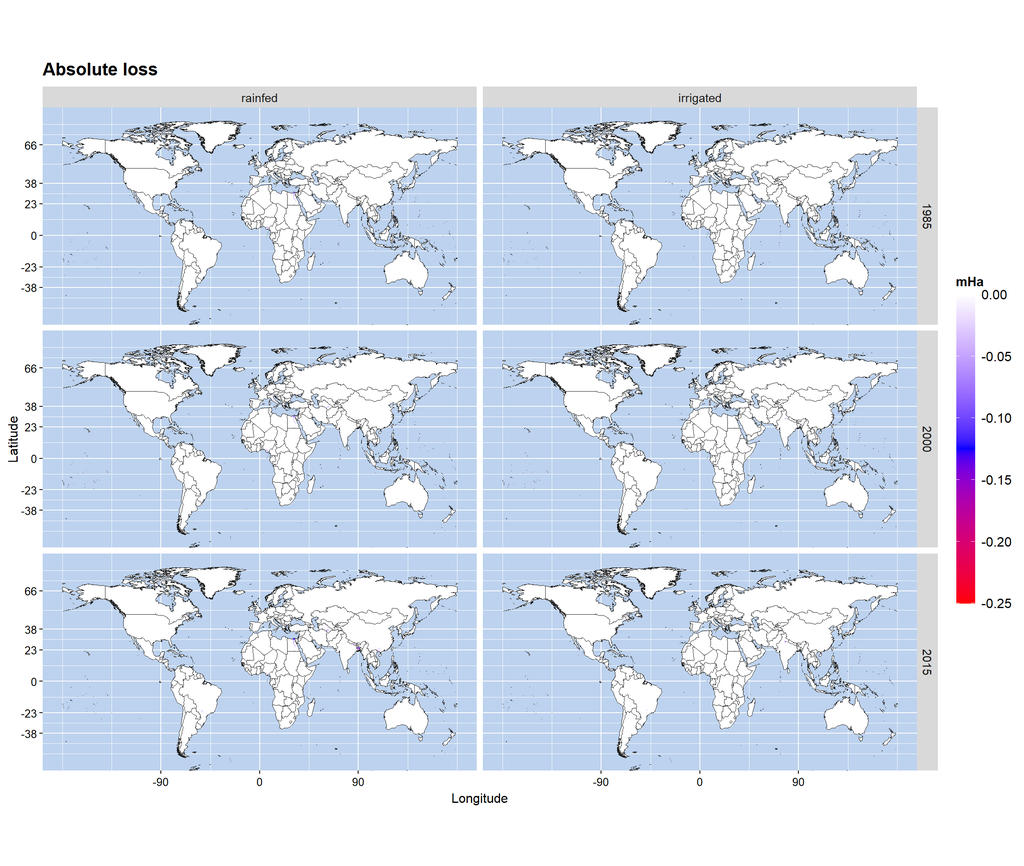

```r
lossCropSum_MP <- toolCoord2Isocell(lossCropSum)

luplot::plotmap2(
  lossCropSum_MP  ,
  legend_range = c(-0.25,0) ,
  midcol = "blue",
  highcol = "white",
  lowcol = "red",
  legendname = "mHa",
  title= "Absolute loss",
  midpoint=-0.125 )
```

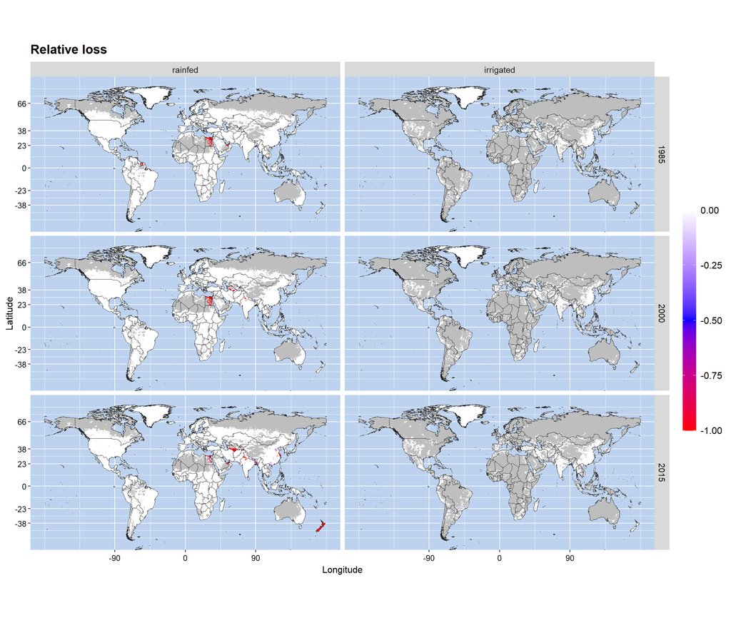

```r
loss_rel_MP <- toolCoord2Isocell(loss_rel)

luplot::plotmap2(
  loss_rel_MP  ,
  legend_range = c(-1,0) ,
  midcol = "blue",
  highcol = "white",
  lowcol = "red",
  legendname = "",
  title= "Relative loss",
  midpoint=-0.5 )
```

## Crop level

```r
crops <- getItems( loss, split = T, dim = "crop")

lossCrop_mHa <- seq(1,length(crops))
`lossCrop_%` <- seq(1,length(crops))
CropArea_mHa <- seq(1,length(crops))



for (c in seq(1,length(crops))) {

  lossCrop_mHa[c] <- sum(loss[,,crops[c] ])
  CropArea_mHa[c] <- sum(harvestedArea[,,crops[c]])
  `lossCrop_%`[c]<- lossCrop_mHa[c] /CropArea_mHa[c]  * 100

}

cropLosstbl <- tibble(crops ,CropArea_mHa ,lossCrop_mHa , `lossCrop_%`)

cropLosstbl  %>% arrange( `lossCrop_%`) %>% select(crops, `lossCrop_%`, lossCrop_mHa) %>%
  mutate_if(is.numeric, function(x)replace_na( round(x,3),0) ) %>%  DT::datatable(.)
```

|  | crops | lossCrop_% | lossCrop_mHa |
| --- | --- | --- | --- |
| 1 | sugr_cane | -3.321 | -2.057 |
| 2 | oilpalm | -1.752 | -0.622 |
| 3 | foddr | -0.777 | -3.11 |
| 4 | cassav_sp | -0.476 | -0.643 |
| 5 | rice_pro | -0.47 | -2.162 |
| 6 | sugr_beet | -0.441 | -0.083 |
| 7 | potato | -0.409 | -0.234 |
| 8 | others | -0.377 | -1.372 |
| 9 | maiz | -0.192 | -0.876 |
| 10 | tece | -0.151 | -1.453 |

[output cut: 7 more lines]

# Cross check that correction solved issues

## annuals CIs

```r
annualsPhysical <- physicalArea - dimSums( harvestedAreaCorrected[,,perennials], "crop")

annaulsCI <-  dimSums( harvestedAreaCorrected[,,annuals], "crop")/ annualsPhysical

cat("Summary of rainfed annuals CI after correction:\n")
```

```
## Summary of rainfed annuals CI after correction:
```

```r
summary(annaulsCI[,,"rainfed"])
```

```
##    Min. 1st Qu.  Median    Mean 3rd Qu.    Max.    NA's
##       0       0       1       1       1       3   86320
```

```r
cat("Summary of irrigated annuals CI after correction:\n")
```

```
## Summary of irrigated annuals CI after correction:
```

```r
summary(annaulsCI[,,"irrigated"])
```

```
##    Min. 1st Qu.  Median    Mean 3rd Qu.    Max.    NA's
##       0       1       1       1       1       3  172818
```

## egypt issue

```r
harvestedAreaCorrectedCropSum <-  dimSums(harvestedAreaCorrected, dim= "crop")

Egypt_iss  <- (harvestedAreaCorrectedCropSum[,,"rainfed"]>10^-7)&(physicalArea[,,"rainfed"]<10^-15)

percent(mean(Egypt_iss))
```

```
## [1] "0.000%"
```